# introduction

This package is built for estimating the causal **path-specific effects** (PSEs) in mediation analysis with multiple ordered mediators for one binary treatment or multiple binary treatments. It provides robust estimators based on influence function theory.

Primary advantages of the package include:

- **Flexible model size**: The number of treatment(s) and mediator(s) is flexible.
- **Flexible decomposition**: This package can return the Natural PSEs and Cumulative PSEs via each mediator ([Xiang Zhou, 2022](https://academic.oup.com/jrsssb/article/84/3/794/7056148)).
- **Flexible pathways**: User can calculate the average potential outcome for any identified pathway(s), as well as the average causal effect by comparing two potential outcome.
- **Flexible models**: The package supports model fitting using `glm/lm`, `dbarts`, `SuperLearner` now. Users can also integrate new models for estimation by modifying the `fl_model_template.R`.
- **Flexible estimators**: This package includes three estimators—Inverse Probability Weighting (IPW), plug-in G-computation, and Efficient Influence Function (EIF). The EIF estimator enhances robustness against model misspecification, ensuring more reliable results.

# 0. Installation:

```r
install.packages("devtools")
library(devtools)

install_github("xxou/flexPaths")
library(flexPaths)
```

# 1. PSEs for Single Treatment

Here, we illustrate the case with two mediators $M_1$ and $M_2$ (the mediator can be high demensional). Let $A$ denote the binary treatment (0 or 1), $Y$ denote the outcome, and $X$ denote the covariates.

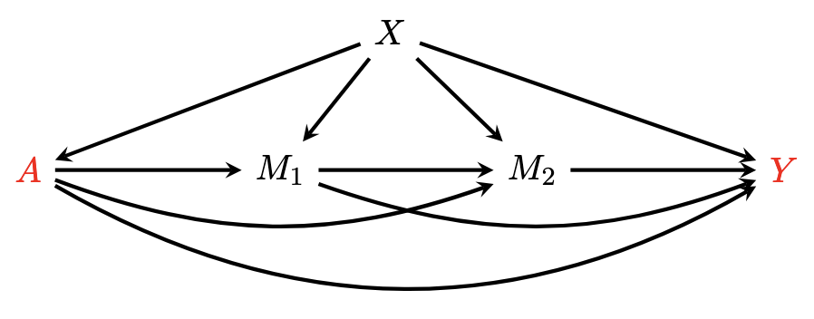

Denote the counterfactual outcome $\phi(a_1, a_2, a) = Y(a,M_1(a_1),M_2(a_2,M_1(a_1)))$ that would be observed if $A$ were set to $a$ and $M_1$ and $M_2$ were set to the natural value they would have taken if $A$ had been $a_1$ and $a_2$, where $(a_1, a_2, a) \in \{0,1\}^3$. For example, $\phi(0, 1, 1)$ means what the outcome would be when individuals were treated $A=1$ and their $M_1$ was set at its natural level as individuals without treated $A=0$. Besides, $Y(a)$ represents $\phi(a, a, a)$, where individuals take its natural values for all mediators.

**Decomposition**:

The effect of specific pathway can be defined as a contrast against $Y(0)$ on a mean scale, and these effects are also called natural path-specific effect:

- $\rho_{A \rightarrow M_1 \leadsto Y} = \mathbb{E} (\phi(1,0,0)) - \mathbb{E} (\phi(0,0,0))$
- $\rho_{A \rightarrow M_2 \rightarrow Y} = \mathbb{E} (\phi(0,1,0)) - \mathbb{E} (\phi(0,0,0))$
- $\rho_{A \rightarrow Y} = \mathbb{E} (\phi(0,0,1)) - \mathbb{E} (\phi(0,0,0))$

Another way to represent PSEs is to decompose the total effect sequentially, and these effects are called cumulative path-specific effect: $\mathbb{E}(Y(1)) - \mathbb{E}(Y(1)) =\rho_{A \rightarrow M_1 \leadsto Y} + \rho_{A \rightarrow M_2 \rightarrow Y} + \rho_{A \rightarrow Y}$

- $\rho_{A \rightarrow M_1 \leadsto Y} = \mathbb{E} (\phi(1,1,1)) - \mathbb{E} (\phi(0,1,1))$
- $\rho_{A \rightarrow M_2 \rightarrow Y} = \mathbb{E} (\phi(0,1,1)) - \mathbb{E} (\phi(0,0,1))$
- $\rho_{A \rightarrow Y} = \mathbb{E} (\phi(0,0,1)) - \mathbb{E} (\phi(0,0,0))$

In the absence of interactions between $A$ and $M$, natural PSEs and cumulative PSEs yield identical results. However, when interactions are present, they display different results except the same direct effect. Meanwhile, natural PSEs cannot be simply summed to represent the total effect. Therefore, these proportions are not analogous to the ``proportion mediated’’ typically.

**Identified pathways**:

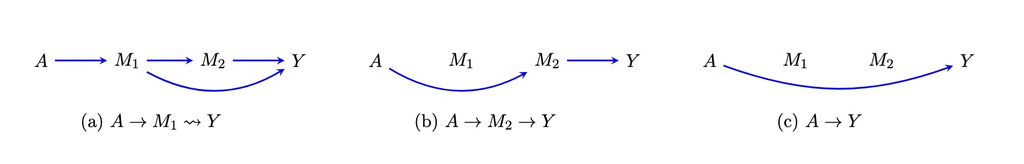

Considering the assumptions of identification, only three pathways above can be identified in our example. $\rho_{A \rightarrow M_1 \leadsto Y}$ captures the effects of all directed pathways from $A$ to $Y$ through $M_1$, i.e., $A \rightarrow M_1 \rightarrow Y$ and $A \rightarrow M_1 \rightarrow M_2 \rightarrow Y$. $\rho_{A \rightarrow M_2 \rightarrow Y}$ captures the effects of all directed pathways from $A$ to $Y$ through $M_2$. $\rho_{A \rightarrow Y}$ captures the direct effect of $A$ on $Y$. For $K$ ordered mediators, only $K+1$ pathways can be identified which are $A \rightarrow Y$ and $A \rightarrow M_k \leadsto Y$ ($k \in \{1, \ldots,K\}$). $\rho_{A \rightarrow M_k \leadsto Y}$ captures all the effect through $M_k$. The identification formula of $\mathbb{E}(\phi(a_1, \ldots,a_K, a))$ is

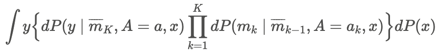

**Models for Estimation**:

- For IPW approach: To estimate $K+1$ PSEs, we need to fit $K+1$ models to estimate propensity score $P(A|X), P(A|X,M_1), \ldots, P(A|X,M_1,\ldots,M_K)$.
- For plug-in G computation: To estimate $K+1$ PSEs, we need to fit $K+1$ models for outcome regression $\mathbb{E}(Y|X), \mathbb{E}(Y|X,M_1), \ldots, \mathbb{E}(Y|X,M_1,\ldots,M_K)$.
- For EIF approach: To estimate $K+1$ PSEs, we need to fit $K+1$ models to estimate both propensity score $P(A|X), P(A|X,M_1), \ldots, P(A|X,M_1,\ldots,M_K)$ and $K+1$ outcome regression $\mathbb{E}(Y|X), \mathbb{E}(Y|X,M_1), \ldots, \mathbb{E}(Y|X,M_1,\ldots,M_K)$.

## 1.1 `pathsInfo`: input needed information for PSEs calculation

We provide data `singTreat` for one treatment with 3 ordered mediators, following the sequence : $A \rightarrow M_1 \rightarrow M_2 \rightarrow M_3 \rightarrow Y$

- A: treat
- $M_1$: med1
- $M_2$: med2_1 and med2_2
- $M_3$: med3
- Y: outcome1 is continuous and outcome2 is binary

```r
data("singTreat")
head(singTreat)
```

```
##   treat          X1          X2       med1     med2_1     med2_2        med3
## 1     1 -0.56047565 -0.99579872 -0.2909027  1.4214143  0.9080483 -0.48342238
## 2     0 -0.23017749 -1.03995504  0.5282772 -1.6131178 -0.6618017 -1.85925365
## 3     1  1.55870831 -0.01798024  0.1072271 -1.5679208  2.0982984 -0.53101464
## 4     0  0.07050839 -0.13217513 -0.5198824 -0.4209952 -1.0630016  0.46861537
## 5     1  0.12928774 -2.54934277  1.3002422  0.2256734  1.3468199  0.01871409
## 6     1  1.71506499  1.04057346  0.3673916  0.5568637  2.1457944  2.10776412
##     outcome1 outcome2
## 1  1.3885202        1
## 2 -0.7139441        1
## 3  1.8068598        0
## 4  1.0421935        1
## 5 -0.3632091        1
## 6  2.1553060        1
```

The `pathsInfo` function takes the necessary input information and verifies whether the inputs meet the specified requirements.

- Data and variables: The input data is specified using `data`, with the treatment variable designated as `A` and the outcome variable as `Y`. Covariates are provided as a vector in `cov_x` while mediators are supplied as an ordered list in `M.list`. Users can reference mediators using indices such as $M_1, \cdots, M_k$ or input them directly in the specified order `M.list=list("med1", c('med2_1', 'med2_2'), 'med3')`. High-dimensional mediators should be represented within a vector.
- Estimation Approach: estimation = “EIF”, “G” or “IPW” for efficient influence function estimator, plug-in G computation estimator and IPW estimator.
- Model methods: Input the model.propensity for IPW; model.outcome for plug-in G computation; model.propensity and model.outcome for EIF.

```r
EIF_fit <- pathsInfo(data = singTreat, A = "treat", Y = "outcome1", cov_x = c("X1", "X2"),
                    M.list = list(M1 = "med1", M2 = c('med2_1', 'med2_2'), M3 = 'med3'),
                    estimation = "EIF",
                    model.outcome = ~SuperLearner(SL.library = c('SL.randomForest','SL.xgboost'),family = gaussian()),
                    model.propensity = ~ bart(verbose = FALSE, ndpost = 200)
)
##  Input checks passed successfully.
```

For `model.outcome` and `model.propensity` methods, you can input either a single formula or a list of formulas. When specifying a model, clearly define the arguments in the corresponding function, except for data, x, y, and formula, which are already provided. In the following example, we use a single formula, `SuperLearner(SL.library = c('SL.randomForest','SL.xgboost'),family = gaussian())`, to fit all outcome regression models: $\mathbb{E}(Y|X)$, $\mathbb{E}(Y|X, M_1)$, $\mathbb{E}(Y|X, M_1, M_2)$, and $\mathbb{E}(Y|X, M_1, M_2, M_3)$.

For the propensity models, models are specified in the following order: - `bart(verbose = FALSE, ndpost = 200)` for $P(A|X)$, - `glm(family = binomial())` for $P(A|X, M_1)$, - `SuperLearner(SL.library = c('SL.randomForest','SL.xgboost'),family = gaussian())` for $P(A|X, M_1, M_2)$, - `glm(family = binomial())` for $P(A|X, M_1, M_2, M_3)$.

```r
EIF_fit <- pathsInfo(data = singTreat, A = "treat", Y = "outcome1", cov_x = c("X1", "X2"),
                    M.list = list(M1 = "med1", M2 = c('med2_1', 'med2_2'), M3 = 'med3'),
                    estimation = "EIF",
                    model.outcome = ~ SuperLearner(SL.library = c('SL.randomForest','SL.xgboost'),family = gaussian()),
                    model.propensity = list(cov_x = ~ bart(verbose = FALSE, ndpost = 200),
                                            M1 = ~ glm(family = binomial()),
                                            M2 = ~ SuperLearner(SL.library = c('SL.randomForest','SL.xgboost'),family = gaussian()),
                                            M3 = ~ glm(family = binomial()))
)
##  Input checks passed successfully.
```

To specify the formula in a glm model, use the `formula` argument within the glm function. This allows you to define the relationship between the outcome and predictor variables clearly.

```r
EIF_fit <- pathsInfo(data = singTreat, A = "treat", Y = "outcome1", cov_x = c("X1", "X2"),
                    M.list = list(M1 = "med1", M2 = c('med2_1', 'med2_2'), M3 = 'med3'),
                    estimation = "EIF",
                    model.outcome = list(cov_x = ~ glm(formula = outcome1 ~X1*X2 ,family = gaussian()),
                                            M1 = ~ glm(formula = outcome1 ~med1+X1*X2, family = gaussian()),
                                            M2 = ~ glm(formula = outcome1 ~med1+med2_1*med2_1+X1*X2, family = gaussian()),
                                            M3 = ~ glm(formula = outcome1 ~med1+med2_1*med2_1+med3+X1*X2, family = gaussian())),
                    model.propensity = list( ~ bart(verbose = FALSE, ndpost = 200))
)
##  Input checks passed successfully.
```

The `model.iter` parameter is set to `NULL` by default. In this case, the iterative model is constructed based on model.outcome, with the family argument replaced by `gaussian` if your function includes a family argument. If you wish to define your own `model.iter`, you can provide either a single formula or a list of formulas ($k-1$) for $E(\cdot| X), E(\cdot| X, M_1), E(\cdot| X, M_1,\cdots,M_{k-1})$.

## 1.2 `pathsEffect`: PSEs through each mediator

```r
EIF_fit <- pathsInfo(data = singTreat, A = "treat", Y = "outcome1", cov_x = c("X1", "X2"),
                    M.list = list(M1 = "med1", M2 = c('med2_1', 'med2_2'), M3 = 'med3'),
                    estimation = "EIF",
                    model.outcome = ~ glm(family = gaussian()),
                    model.propensity = ~ glm(family = binomial())
)
##  Input checks passed successfully.
```

`pathsEffect` function returns the effects through each mediator. Users need to provide the `pathsInfo` and select a decomposition method to obtain the PSEs. In the presence of interactions, the results from the two decomposition methods will not align, except for the total and direct effects.

```r
results_refer0 <- pathsEffect(pathsInfo = EIF_fit, decomposition = "refer0", scale = "diff", CI_level = 0.95)
results_refer0
```

```
##
## Causal Paths Analysis: 0 reference decomposition ; scale: diff ; estimation: EIF
##
## Call: pathsEffect(pathsInfo = EIF_fit, decomposition = "refer0", scale = "diff",
##     CI_level = 0.95)
##
##
## Causal Paths Estimates:
##
##                      Path      Effect         SE    CI.lower   CI.upper P.value
## 1           A->M1->...->Y 0.188162979 0.03165008  0.12612996 0.25019600  0.0000
## 2           A->M2->...->Y 0.069235296 0.02627361  0.01773997 0.12073062  0.0084
## 3           A->M3->...->Y 0.007333175 0.01016017 -0.01258040 0.02724675  0.4704
## 4                    A->Y 0.513165676 0.06549502  0.38479779 0.64153356  0.0000
## 5 total effect: A->...->Y 0.749385989 0.06955366  0.61306333 0.88570865  0.0000
```

```r
results_seq <- pathsEffect(pathsInfo = EIF_fit, decomposition = "sequential", scale = "diff", CI_level = 0.95)
results_seq
```

```
##
## Causal Paths Analysis: sequential decomposition ; scale: diff ; estimation: EIF
##
## Call: pathsEffect(pathsInfo = EIF_fit, decomposition = "sequential",
##     scale = "diff", CI_level = 0.95)
##
##
## Causal Paths Estimates:
##
##                      Path       Effect         SE    CI.lower   CI.upper
## 1           A->M1->...->Y  0.159502029 0.03112555  0.09849708 0.22050698
## 2           A->M2->...->Y  0.080741578 0.02125415  0.03908421 0.12239895
## 3           A->M3->...->Y -0.004023294 0.01008338 -0.02378635 0.01573976
## 4                    A->Y  0.513165676 0.06549502  0.38479779 0.64153356
## 5 total effect: A->...->Y  0.749385989 0.06955366  0.61306333 0.88570865
##   P.value
## 1  0.0000
## 2  0.0001
## 3  0.6899
## 4  0.0000
## 5  0.0000
```

The standard error and confidence intervals can also be estimated using the bootstrap method. Set `nboot` to specify the number of bootstrap iterations, and if `m.cores` is set to a positive integer, parallel computation will be utilized.

```r
results_boot <- pathsEffect( pathsInfo = EIF_fit, decomposition = "sequential", scale = "diff", CI_level = 0.95, nboot = 10, m.cores = NULL)

results_boot <- pathsEffect( pathsInfo = EIF_fit, decomposition = "sequential", scale = "diff", CI_level = 0.95, nboot = 10, m.cores = 3)
results_boot
```

```
##
## Causal Paths Analysis: sequential decomposition ; scale: diff ; estimation: EIF
##
## Call: pathsEffect(pathsInfo = EIF_fit, decomposition = "sequential",
##     scale = "diff", CI_level = 0.95, nboot = 10, m.cores = 3)
##
##
## boot strap results:
##
##                      Path       Effect     boot.SE boot.CI.lower boot.CI.upper
## 1           A->M1->...->Y  0.159502029 0.030552651    0.13217829   0.217933333
## 2           A->M2->...->Y  0.080741578 0.021884606    0.05035844   0.116561597
## 3           A->M3->...->Y -0.004023294 0.006860738   -0.01192027   0.009206029
## 4                    A->Y  0.513165676 0.062449285    0.37337175   0.574256259
## 5 total effect: A->...->Y  0.749385989 0.060163186    0.62786866   0.817215450
##   nboot boot.P.value
## 1    10       0.0000
## 2    10       0.0002
## 3    10       0.5576
## 4    10       0.0000
## 5    10       0.0000
```

## 1.3 `flexEffect`: PSE for flexible pathway(s)

The `flexEffect` function can get effect for any identified path or combined path by comparing two potential outcome from the function `flexPotential`.

The `flexPotential` will calculate the **potential outcome** for user-specified counterfactual values. For example, potential_outcome0 returns the potential outcome for individuals in treatment = 0 whose mediators were set as they had not received treatment. The argument active = $c(a_1, a_2, a_3, a)$ specifies the counterfatual value of $A$ for $M_1$, $M_2$, $M_3$ and $Y$ orderly.

```r
potential_outcome0 <- flexPotential(pathsInfo = EIF_fit, active = c(0, 0, 0, 0))
potential_outcome1 <- flexPotential(pathsInfo = EIF_fit, active = c(1, 0, 1, 1))
potential_outcome2 <- flexPotential(pathsInfo = EIF_fit, active = c(1, 0, 0, 1))
potential_outcome3 <- flexPotential(pathsInfo = EIF_fit, active = c(1, 0, 0, 0))
```

After obtaining the potential outcomes from `flexPotential`, we can use the `flexEffect` to calculate the effects by comparing p1 and p2. For example, flex_results1 represents the PSEs: $\mathbb{E}(\phi(1,0,1,1)) - \mathbb{E}(\phi(0, 0, 0, 0))$ which captures the effect mediated through $M_1$, $M_3$ and direct effect $A \rightarrow Y$:

```r
flex_results1 <- flexEffect(p1 = potential_outcome1,
                            p0 = potential_outcome0, scale = "diff", CI_level = 0.95,nboot = 10, m.cores = 3)
flex_results1
```

```
##
## Flexible Paths Analysis
##
## Call: flexEffect(p1 = potential_outcome1, p0 = potential_outcome0,
##     scale = "diff", CI_level = 0.95, nboot = 10, m.cores = 3)
##
##
## boot strap results:
##
##         active   Effect    boot.SE boot.CI.lower boot.CI.upper nboot
## 1 1011 vs 0000 0.674418 0.07922733      0.572325     0.7829498    10
##   boot.P.value
## 1            0
```

To simplify multiple comparisons, p1 and p2 can be provided as lists. Note the following:

1. When p1 and p2 have the same length, `flexEffect` will compare each element of p1 with the corresponding element of p0. For instance, it will compare potential_outcome1 with potential_outcome0, and potential_outcome2 with potential_outcome3 here.

```r
flex_results <- flexEffect(p1 = list(potential_outcome1, potential_outcome2),
                           p0 = list(potential_outcome0, potential_outcome3), scale = "diff", CI_level = 0.95,nboot = 5)
flex_results
```

```
##
## Flexible Paths Analysis
##
## Call: flexEffect(p1 = list(potential_outcome1, potential_outcome2),
##     p0 = list(potential_outcome0, potential_outcome3), scale = "diff",
##     CI_level = 0.95, nboot = 5)
##
##
## boot strap results:
##
##         active    Effect    boot.SE boot.CI.lower boot.CI.upper nboot
## 1 1001 vs 1000 0.4894581 0.05571227     0.4501180     0.5698079     5
## 2 1011 vs 0000 0.6744180 0.03977888     0.6300972     0.7302270     5
##   boot.P.value
## 1            0
## 2            0
```

2. When either p1 or p2 contains a single input and the other is a list, flexEffect will compare that single element with each element in the list. For example, it will compare potential_outcome1 with potential_outcome0, and potential_outcome2 with potential_outcome0.

```r
flex_results <- flexEffect(p1 = list(potential_outcome1, potential_outcome2),
                           p0 = potential_outcome0, scale = "diff", CI_level = 0.95,nboot = 5)
flex_results
```

```
##
## Flexible Paths Analysis
##
## Call: flexEffect(p1 = list(potential_outcome1, potential_outcome2),
##     p0 = potential_outcome0, scale = "diff", CI_level = 0.95,
##     nboot = 5)
##
##
## boot strap results:
##
##         active   Effect    boot.SE boot.CI.lower boot.CI.upper nboot
## 1 1001 vs 0000 0.677621 0.02284784     0.6725228     0.7306551     5
## 2 1011 vs 0000 0.674418 0.03079662     0.6660273     0.7379961     5
##   boot.P.value
## 1            0
## 2            0
```

Similarly, this approach allows for the comparison of potential_outcome1 versus potential_outcome2, and potential_outcome1 versus potential_outcome3.

```r
flex_results <- flexEffect(p1 = list(potential_outcome1),
                           p0 = list(potential_outcome2,potential_outcome3), scale = "diff", CI_level = 0.95,nboot = 5)
flex_results
```

```
##
## Flexible Paths Analysis
##
## Call: flexEffect(p1 = list(potential_outcome1), p0 = list(potential_outcome2,
##     potential_outcome3), scale = "diff", CI_level = 0.95, nboot = 5)
##
##
## boot strap results:
##
##         active       Effect     boot.SE boot.CI.lower boot.CI.upper nboot
## 1 1011 vs 1000  0.486255031 0.100306693   0.378251241   0.622821861     5
## 2 1011 vs 1001 -0.003203024 0.006995373  -0.009210328   0.007620199     5
##   boot.P.value
## 1        0.000
## 2        0.647
```

# 2. PSEs for Multiple Treatments

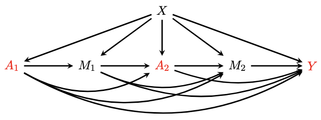

The sequence of treatments and mediators follows the order: $A \rightarrow M_1 \rightarrow A_2 \rightarrow M_2 \rightarrow Y$.

Denote the counterfactual outcome $\phi(a_{11}, a_{12}, a_{10}, a_{22}, a_{20} ) = Y(a_{10}, a_{20},M_1(a_{11}),M_2(a_{12}, a_{22},M_1(a_{11})))$, where $a_{ij}$ represents the counterfactual value of treatment $i$ for mediator $j$ ($j = 0$ represents outcome $Y$). Notably, since $M_1$ occurs before $A_2$, thus there is no counterfactual value of $A_2$ for $M_1$, and thus $a_{21}$ is $NA$. Taking the direct effect of treatment $A_1$ and treatment $A_2$ as an example, $\phi(a_{11}=0, a_{12}=0, a_{10}=1, a_{22}=0, a_{20}=1 )$ means what the outcome would be when individuals were treated with both $A_1=1$ and $A_2=1$ and the mediator $M_1$ was set at its natural level for those without treatment 1 ($A_1=0$), as well as mediator $M_2$ was set at its natural level for those without both treatments 1 ($A_1=0$) and treatment 2 $A_2=0$).

This can be represented in matrix form, where rows represent treatments and columns represent mediators:

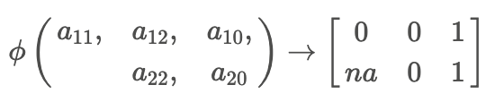

**Models for Estimation**: Given the complexity of models involving multiple treatments, this package applies a consistent modeling technique across all propensity models and another across all outcome regression models.

- IPW Approach: Users must select a single modeling technique to fit all propensity models.
- Plug-in G Computation: Users must choose one modeling technique to fit all outcome regression models.
- EIF Approach: Users must select one modeling technique for all propensity models and a separate technique for all outcome regression models.

## 2.1 `pathsInfo`: input needed information for PSEs calculation

We provide data `multiTreat` for 3 treatments with 6 ordered mediators, following the sequence: $A_1 \rightarrow A_2 \rightarrow M_1 \rightarrow M_2 \rightarrow M_3 \rightarrow A_3 \rightarrow M_4 \rightarrow M_5 \rightarrow M_6 \rightarrow Y$.

- A: t1, t2, t3
- $M_1$: m1
- $M_2$: m2
- $M_3$: m3
- $M_4$: m4
- $M_5$: m5
- $M_6$: m6
- Y: continuous Y

```r
data("multiTreat")
head(multiTreat)
```

```
##            X t1 t2 t3         m1         m2         m3          m4          m5
## 1  0.5110004  1  1  1  1.9973170  0.6401092  0.4582243 -0.27523814 -0.09387742
## 2  1.8079928  0  1  0  1.1450254  0.8124416  2.1308472  1.64126511  1.37869655
## 3 -1.7026150  0  0  1 -1.1258939  1.1395740  1.2105479  0.40682505  0.67242152
## 4  0.2874488  0  0  1  0.1496110  0.2528034 -1.0118998  0.25536960  0.91400475
## 5 -0.2691142  0  1  0 -0.4372909 -0.9858409  0.0244613  0.53140872  0.35057702
## 6 -0.3795247  0  1  1  0.1966683  0.6989559  1.0743453  0.01092031  1.57590275
##            m6          Y
## 1 -0.07222626  0.8100211
## 2  3.74522822  9.7240020
## 3 -0.77182524 -0.7412953
## 4  0.73485597  0.9291092
## 5 -0.12227943  0.6170001
## 6  0.38646757  2.0241894
```

The `pathsInfo` function operates the same way as in the single treatment case, except when a vector of treatments is provided in A.

```r
mfit<- pathsInfo(data = multiTreat,
                Y = "Y",
                A = c("t1","t2","t3"),
                cov_x = "X",
                M.list = list(
                  M1 = 'm1',
                  M2 = 'm2',
                  M3 = 'm3',
                  M4 = 'm4',
                  M5 = 'm5',
                  M6 = 'm6'
                ),
                estimation = "EIF",
                model.propensity =list( ~  glm(family = binomial())),
                model.outcome = list( ~SuperLearner(SL.library = "SL.mean",family = gaussian())),
                model.iter  = list(~glm(family = gaussian()))
)
##  Input checks passed successfully.
```

## 2.2 `flexEffect`: PSE for flexible pathway(s)

It is the same function as the single treatment case. It can also get effect for any identified path or combined path by comparing two potential outcome from the function `mflexPotential`.

The `mflexPotential` will calculate the **potential outcome** for user-specified counterfactual values in the scenario of multiple treatments. In the example data multiTreat, the sequence of treatments and mediators is $A_1 \rightarrow A_2 \rightarrow M_1 \rightarrow M_2 \rightarrow M_3 \rightarrow A_3 \rightarrow M_4 \rightarrow M_5 \rightarrow M_6 \rightarrow Y$. The counterfactual values matrix can be expressed as:

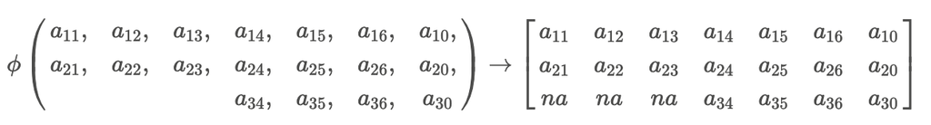

In the function `mflexPotential`, inputs of counterfactual values are specified using a list. Within the list `active`, each element is named according to the corresponding treatment order $a_i$, and should contain a vector of values for $M_1, \cdots,M_6,Y$. Since treatment 3 is after $M_3$, the first three values in the `a3` vector are set to **NA**.

```r
mp1<-mflexPotential(active = list(a1=c(0,1,0,0,1,0,0),
                                  a2=c(1,0,1,1,1,0,0),
                                  a3=c(NA,NA,NA,1,0,0,0)),mfit)
mp2<-mflexPotential(active = list(a1=c(0,0,0,0,1,0,0),
                                  a2=c(0,0,0,1,1,0,0),
                                  a3=c(NA,NA,NA,1,0,0,0)),mfit)
```

We can use the `flexEffect` to calculate the effects by comparing p1 and p2. The flexible inputs of p1 and p2 are the same as in section 1.3.

```r
flexEffect(p1 = mp1, p0 = mp2, scale = "diff", CI_level = 0.95, nboot =10 , m.cores = 6)
```

```
##
## Flexible Paths Analysis
##
## Call: flexEffect(p1 = mp1, p0 = mp2, scale = "diff", CI_level = 0.95,
##     nboot = 10, m.cores = 6)
##
##
## boot strap results:
##
##                                         active    Effect   boot.SE
## 1 0100100;1011100;1000 vs 0000100;0001100;1000 0.2406978 0.1401465
##   boot.CI.lower boot.CI.upper nboot boot.P.value
## 1   -0.02754389     0.3967642    10       0.0859
```